# Making Euchre Bids With Machine Learning

## Decision Trees

Decision trees are the most interesting because unlike all the created models provided, decision trees are very interpretative and provide a clear action of what call to make based on a list of conditions.

It is the most practical model to use in a real-life Euchre game.

### Create initial decision tree

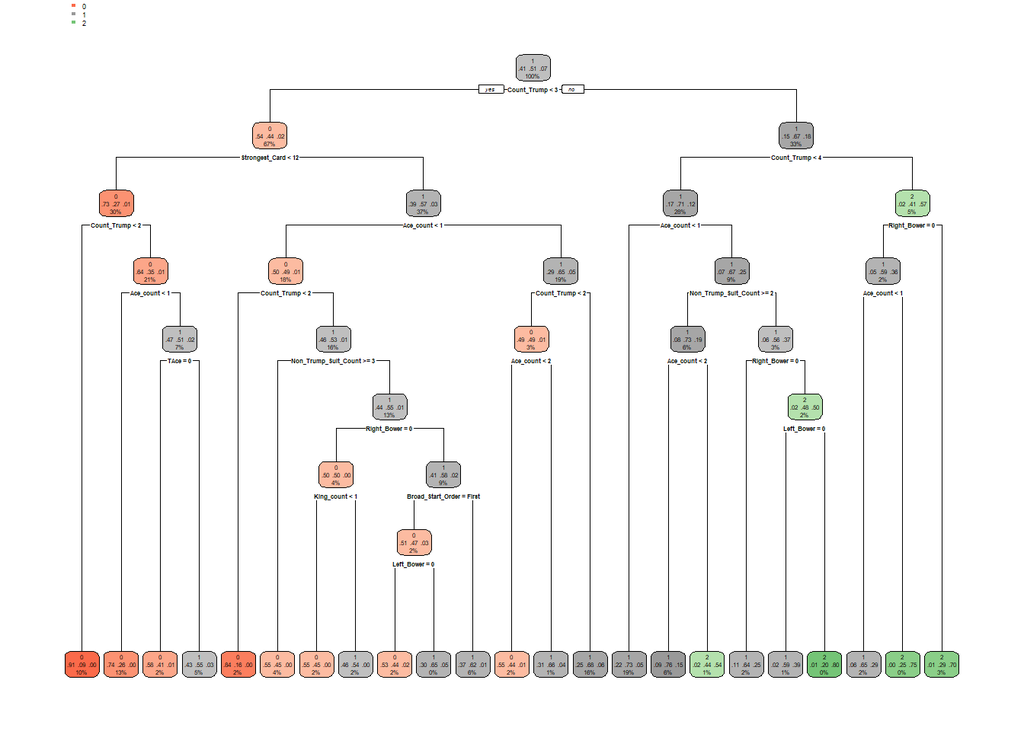

```r
default.large.tree = rpart(correct_call ~., data = euchre_turn_down_train, method = "class", control = rpart.control(cp = .001))
rpart.plot::rpart.plot(default.large.tree)
```

### Prune the tree to make an easier to follow model

```r
printcp(default.large.tree)
```

```
##
## Classification tree:
## rpart(formula = correct_call ~ ., data = euchre_turn_down_train,
##     method = "class", control = rpart.control(cp = 0.001))
##
## Variables actually used in tree construction:
## [1] Ace_count            Broad_Start_Order    Count_Trump
## [4] King_count           Left_Bower           Non_Trump_Suit_Count
## [7] Right_Bower          Strongest_Card       TAce
##
## Root node error: 38988/80000 = 0.48735
##
## n= 80000
##
##           CP nsplit rel error  xerror      xstd
## 1  0.1480969      0   1.00000 1.00000 0.0036261
## 2  0.1363753      1   0.85190 0.85190 0.0035747
## 3  0.0158254      2   0.71553 0.71553 0.0034573
## 4  0.0129399      3   0.69970 0.69970 0.0034390
## 5  0.0088489      5   0.67382 0.67382 0.0034070
## 6  0.0072843      6   0.66497 0.66508 0.0033955
## 7  0.0045997      7   0.65769 0.65769 0.0033856
## 8  0.0027701     10   0.64389 0.64779 0.0033719
## 9  0.0026034     11   0.64112 0.64202 0.0033637
## 10 0.0018980     13   0.63591 0.63591 0.0033549
## 11 0.0018724     15   0.63212 0.63484 0.0033534
## 12 0.0016415     16   0.63025 0.63363 0.0033516
## 13 0.0012889     17   0.62860 0.63007 0.0033464
## 14 0.0010000     22   0.62214 0.62409 0.0033375
```

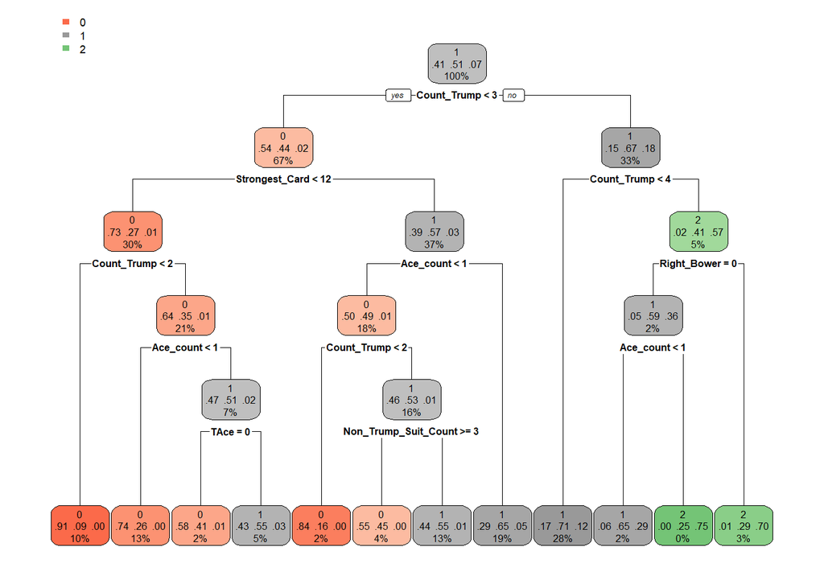

```r
default.pruned.tree = rpart(correct_call ~., data = euchre_turn_down_train, method = "class", control = rpart.control(cp = 0.0026034)) # nsplit = 11
rpart.plot::rpart.plot(default.pruned.tree)
```

This tree gives a great list of conditions that should be satisfied when making a bid for presumably the best suit in hand (excluding the turned down suit).

#### **The player should PASS if:**

There are 0 trump cards in hand

**OR**

There is 1 trump card in hand  
AND  
That trump card is weaker than the Left Bower  
AND/OR  
There are no non-trump aces in hand

**OR**

There are 2 trump cards in hand  
AND  
The strongest card in hand is weaker than the Left Bower  
AND  
There are no non-trump aces in hand

**OR**

There are 2 trump cards in hand  
AND  
The strongest card in hand is weaker than the Left Bower  
AND  
There is at least 1 non-trump ace in hand  
AND  
The trump ace is NOT in hand

**OR**

There are 2 trump cards in hand  
AND  
The strongest card is at least as strong as the Left Bower  
AND  
There are no non-trump aces in hand  
AND  
All 3 non-trump suits are in hand

#### **The player should order trump if:**

There are 1-2 trump cards in hand  
AND  
The strongest card in hand is at least as strong as the Left Bower  
AND  
There is at least one non-trump ace in hand

**OR**

There are 2 trump cards in hand  
AND  
The strongest card in hand is weaker than the Left Bower  
AND  
There is at least 1 non-trump ace in hand  
AND  
The trump ace is in hand

**OR**

There are 2 trump cards in hand  
AND  
The strongest card in hand is at least as strong as the Left Bower  
AND  
There are no non-trump aces in hand  
AND  
All 3 distinct non-trump suits are NOT present in hand

**OR**

There are 3 trump cards in hand

**OR**

There are 4-5 trump cards in hand  
AND  
The Right Bower is NOT present in hand  
AND  
There are no non-trump aces in hand

#### **The player should go alone if:**

There are 4-5 trump cards in hand  
AND  
The Right Bower is present in hand  
AND/OR  
There is at least 1 non-trump ace in hand

### Create Weighted Tree

To create this weighted tree, loss costs will be assigned to each misclassification category. These loss cost values get calculated by using the default tree model to predict what call should be made. The difference between the points won off the correct call and the points won off the predicted call are calculated as the loss cost. The average loss cost for each misclassification category (predicted 0s actual 1s), (predicted 1s actual 2s), etc. get stored as the parameter values used when creating the new tree.

```r
# Create average loss cost values for each misclassification category
build_results(model = default.pruned.tree)
find_loss_cost(results_default.pruned.tree, 'model_bid', return_avg_cost = FALSE, save_ind_costs = TRUE)
```

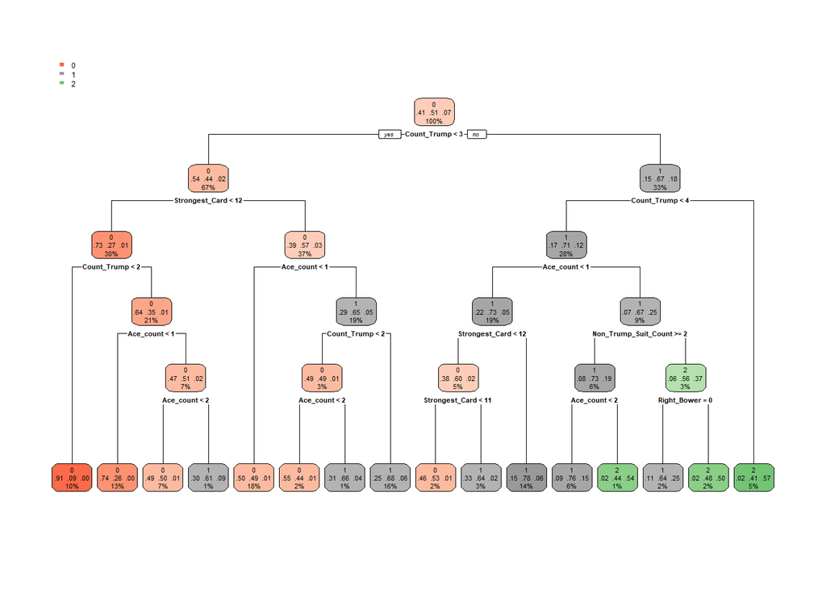

```r
weighted.large.tree = rpart(correct_call ~., data = euchre_turn_down_train, method = "class",
                      parms = list(loss = matrix(c(0, p0_a1, p0_a2, p1_a0, 0, p1_a2, p2_a0, p2_a1, 0), nrow = 3)), control = rpart.control(cp = .001))
rpart.plot::rpart.plot(weighted.large.tree)
```

### Prune the tree to make an easier to follow model

```r
printcp(weighted.large.tree)
```

```
##
## Classification tree:
## rpart(formula = correct_call ~ ., data = euchre_turn_down_train,
##     method = "class", parms = list(loss = matrix(c(0, p0_a1,
##         p0_a2, p1_a0, 0, p1_a2, p2_a0, p2_a1, 0), nrow = 3)),
##     control = rpart.control(cp = 0.001))
##
## Variables actually used in tree construction:
## [1] Ace_count            Count_Trump          Non_Trump_Suit_Count
## [4] Right_Bower          Strongest_Card
##
## Root node error: 67663/80000 = 0.84579
##
## n= 80000
##
##          CP nsplit rel error  xerror      xstd
## 1 0.3564977      0   1.00000 1.30673 0.0038871
## 2 0.0334991      1   0.64350 0.79534 0.0035425
## 3 0.0271022      3   0.57650 0.57763 0.0030401
## 4 0.0133086      4   0.54940 0.58923 0.0031200
## 5 0.0022809      5   0.53609 0.60408 0.0031878
## 6 0.0018598     11   0.52127 0.62335 0.0032615
## 7 0.0011662     12   0.51941 0.61661 0.0032448
## 8 0.0010000     15   0.51591 0.60619 0.0032156
```

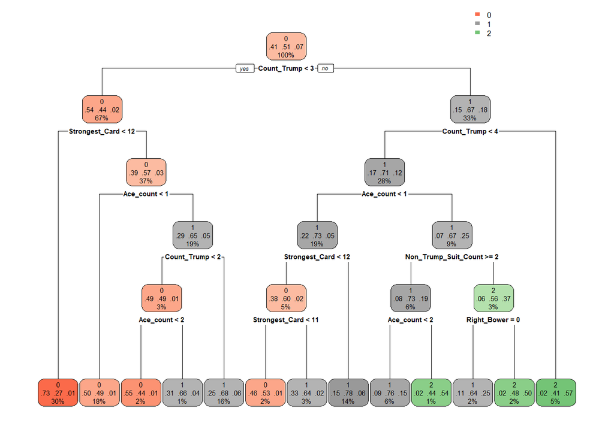

```r
weighted.pruned.tree = rpart(correct_call ~., data = euchre_turn_down_train, method = "class",
                      parms = list(loss = matrix(c(0, p0_a1, p0_a2, p1_a0, 0, p1_a2, p2_a0, p2_a1, 0), nrow = 3)), control = rpart.control(cp = 0.0011662)) # nsplit = 12
rpart.plot::rpart.plot(weighted.pruned.tree)
```

This tree looks to be a little more complex than the pruned default tree. In fact, there only seems to be one additional split.

This tree also gives a great list of conditions that should be satisfied when making a bid for the presumed best suit in hand.

#### **The player should PASS if:**

There are 0 trump cards in hand

**OR**

There is 1 trump card in hand  
AND  
That trump card is at least as strong as the Left Bower  
AND  
There is exactly 1 non-trump ace in hand

**OR**

There are 1-2 trump cards in hand  
AND  
The strongest card in hand is weaker than the Left Bower

**OR**

There are 1-2 trump cards in hand  
AND  
The strongest card in hand is at least as strong as the Left Bower  
AND  
There are no non-trump aces in hand

**OR**

There are 3 trump cards in hand  
AND  
There are no non-trump aces in hand  
AND  
The strongest card in hand is weaker than the trump ace

#### **The player should order trump if:**

There is 1 trump card in hand  
AND  
That trump card is at least as strong as the Left Bower  
AND  
There are at least 2 non-trump aces in hand

**OR**

There are 2 trump cards in hand  
AND  
The strongest card is at least as strong as the Left Bower  
AND  
There is at least 1 non-trump ace in hand

**OR**

There are 3 trump cards in hand  
AND  
There are no non-trump aces in hand  
AND  
The strongest card in hand is at least as strong as the trump ace

**OR**

There are 3 trump cards in hand  
AND  
There is at least one non-trump ace in hand  
AND  
There are less than 2 distinct non-trump suits in hand  
AND  
The Right Bower is NOT present in hand

**OR**

There are 3 trump cards in hand  
AND  
There are 2 distinct non-trump suits in hand  
AND  
There is exactly 1 non-trump ace in hand

#### **The player should go alone if:**

There are 3 trump cards in hand  
AND  
There is at least 1 non-trump ace in hand  
AND  
There are less than 2 distinct non-trump suits in hand  
AND  
The Right Bower is present in hand

**OR**

There are 3 trump cards in hand  
AND  
There are 2 non-trump aces in hand

**OR**

There are 4-5 trump cards in hand

**These trees provide good recommendations for what decisions to make, but they are by no means perfect. There are definitely exceptions that just happen to get grouped in a specific leaf.**

**It is also important to note that for the pink leaf scenarios, bidding trump is recommended in dire situations (when the opposing team has 9 points and only needs one point left to score). A little less than half of the records in the pink leafs are successful bids, so it would not hurt to bid trump in these scenarios. It would not be a good idea give a team that only needs one point an opportunity to bid trump.**

**On the flip side, the green leaf scenarios should only “order trump alone” if the player’s team has 7 points or less. This is because if a team has 8 points, both players can play the round and can win 2 points, which would win the game.**

**Finally, not all the leafs should necessarily be followed all the time. For example, if there are 4 weak trump cards in hand, maybe it would make more sense to order trump NOT alone instead of going alone.**

### Evaluate results for the decision trees

| model_name | loss_cost | macro_auc | macro_f1 | accuracy | p_euchred_calls | p_missed_calls |
| --- | --- | --- | --- | --- | --- | --- |
| default.large.tree | 0.52210 | 0.8177085 | 0.4753822 | 0.69420 | 0.2375942 | 0.2735407 |
| default.pruned.tree | 0.55445 | 0.7953158 | 0.4441396 | 0.68235 | 0.2665998 | 0.2414307 |
| weighted.large.tree | 0.50860 | 0.8164407 | 0.4756771 | 0.67410 | 0.2188739 | 0.3273610 |
| weighted.pruned.tree | 0.49890 | 0.7977183 | 0.4712634 | 0.66840 | 0.1818368 | 0.3611791 |

The **weighted** pruned tree yields a much better loss cost compared to the **default** pruned tree. Although the weighted pruned tree has a leaf where a player could make a bid with 1 trump card, the additional logic for that leaf makes it reliable to do so. Furthermore, the sorting process is also more lenient on classifying 2s and there’s a lower risk of getting euchred while using this model. Therefore, the **weighted pruned tree** model will be used.

```r
euchre_turn_down.tree = weighted.pruned.tree
```

## Random Forest

Ideally, this model can be used to determine which predictors are the most important and if the predictions align with the other created models.

A random forest uses many decision trees and combines the outputs to reach a singular result.

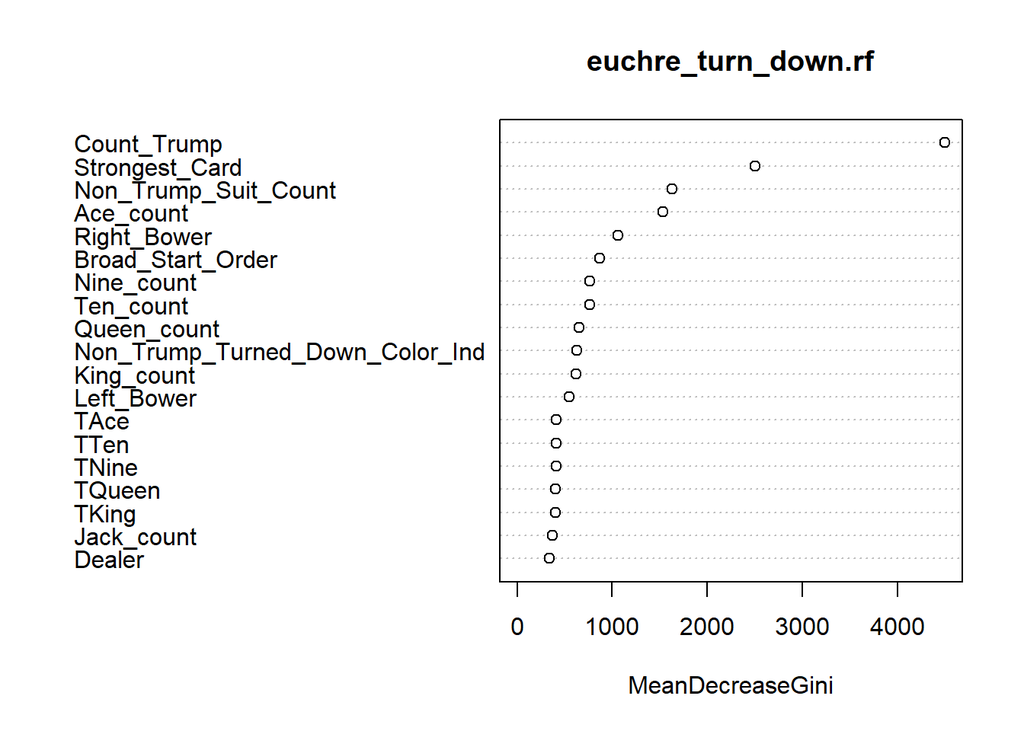

```r
euchre_turn_down.rf = randomForest(correct_call ~ ., data = euchre_turn_down_train, ntree = 300, mtry = 5, nodesize = 1, importance = TRUE)
varImpPlot(euchre_turn_down.rf, type = 2)
```

The random forest importance plot shows that the top 6 most important predictors are the count of trump cards, the strongest card value, the count of distinct non-trump suits, the count of non-trump aces, whether the Right Bower is present, and the order in which the player will be starting in. This is consistent with the predictors selected in other models.

### Show random forest model performance

| model_name | loss_cost | macro_auc | macro_f1 | accuracy | p_euchred_calls | p_missed_calls |
| --- | --- | --- | --- | --- | --- | --- |
| euchre_turn_down.rf | 0.5285 | 0.8178694 | 0.4677295 | 0.68895 | 0.2492563 | 0.2691247 |

From a glance, the result metrics don’t seem to be vastly different than the other models. Therefore, it can be fair to assume that the insights found from the random forest model can be applied to the other models.

## K Nearest Neighbors

In order to build K nearest neighbors models, all the data needs to be numerical. In addition, it is important that all variables are normalized. This way, all variables carry the same amount of weight when making predictions.

```r
# Create dummy variables for categorical fields
euchre_turn_down_train_w_dummies = dummy_cols(euchre_turn_down_train, select_columns = "Broad_Start_Order", remove_selected_columns = TRUE)

euchre_turn_down_test_w_dummies = dummy_cols(euchre_turn_down_test, select_columns = "Broad_Start_Order", remove_selected_columns = TRUE)

# Normalize all predictor variables so each value is between zero and one
euchre_turn_down_train_w_dummies.norm = euchre_turn_down_train_w_dummies
euchre_turn_down_test_w_dummies.norm = euchre_turn_down_test_w_dummies

cols = colnames(euchre_turn_down_train_w_dummies.norm[,-19])
for(i in cols){
  euchre_turn_down_train_w_dummies.norm[[i]] = (euchre_turn_down_train_w_dummies.norm[[i]] - min(euchre_turn_down_train_w_dummies[[i]]))/(max(euchre_turn_down_train_w_dummies[[i]]) - min(euchre_turn_down_train_w_dummies[[i]]))
  euchre_turn_down_test_w_dummies.norm[[i]] = (euchre_turn_down_test_w_dummies.norm[[i]] - min(euchre_turn_down_train_w_dummies[[i]]))/(max(euchre_turn_down_train_w_dummies[[i]]) - min(euchre_turn_down_train_w_dummies[[i]]))
}
```

### K Nearest Neighbors with all variables

```r
# Create dataframe with unique observations to prevent excess number of ties
distinct_euchre_turn_down_train_w_dummies.norm = unique(euchre_turn_down_train_w_dummies.norm)

lg_loss_cost.df = data.frame(k=seq(26, 50, 1),
                          loss_cost = rep(0, 25))
# Look for which K value performs the best. Look for K values between 26-50 to use
for(i in 1:25){
  knn.pred = knn(distinct_euchre_turn_down_train_w_dummies.norm[,-19],
                 euchre_turn_down_test_w_dummies.norm[,-19],
                 cl = distinct_euchre_turn_down_train_w_dummies.norm$correct_call,
                 k=i+25)
  result.iter = results_test
  result.iter$model_bid = knn.pred
  lg_loss_cost.df[i,2] = find_loss_cost(result.iter, 'model_bid') # Record loss cost of model when testing for each K
}
# Use the average lowest loss cost value to get the best K value
best_full_k = lg_loss_cost.df %>%
  mutate(min_score = min(loss_cost)) %>%
  filter(loss_cost == min_score) %>%
  mutate(min_k = min(k)) %>%
  filter(k == min_k)
best_full_k = best_full_k$k

# Build KNN model with the best performing K value
euchre_turn_down.full.knn = knn(train = distinct_euchre_turn_down_train_w_dummies.norm[,-19],
                              test = euchre_turn_down_test_w_dummies.norm[,-19],
                              cl = distinct_euchre_turn_down_train_w_dummies.norm$correct_call,
                              k=best_full_k)

paste0('The best K for the full KNN model is ', best_full_k)
```

```
## [1] "The best K for the full KNN model is 42"
```

### K Nearest Neighbors with the 6 most important variables from the random forest model

```r
# Use the top 6 rf variables
top_rf_var = c('Count_Trump', 'Strongest_Card', 'Ace_count', 'Non_Trump_Suit_Count', 'Right_Bower', 'Broad_Start_Order')
euchre_turn_down_train_w_dummies.norm_subset = euchre_turn_down_train_w_dummies.norm %>%
  select(matches(top_rf_var), 'correct_call')
euchre_turn_down_test_w_dummies.norm_subset = euchre_turn_down_test_w_dummies.norm %>%
  select(matches(top_rf_var), 'correct_call')

distinct_euchre_turn_down_train_w_dummies.norm_subset = unique(euchre_turn_down_train_w_dummies.norm_subset)

sm_loss_cost.df = data.frame(k=seq(26, 50, 1),
                             loss_cost = rep(0, 25))
# Look for which K value performs the best. Look for K values between 26-50 to use
for(i in 1:25){
  knn.pred = knn(distinct_euchre_turn_down_train_w_dummies.norm_subset[,-9],
                 euchre_turn_down_test_w_dummies.norm_subset[,-9],
                 cl = distinct_euchre_turn_down_train_w_dummies.norm_subset$correct_call,
                 k=i+25)
  result.iter = results_test
  result.iter$model_bid = knn.pred
  sm_loss_cost.df[i,2] = find_loss_cost(result.iter, 'model_bid') # Record loss cost of model when testing for each K
}
# Use the average lowest loss cost value to get the best K value
best_small_k = sm_loss_cost.df %>%
  mutate(min_score = min(loss_cost)) %>%
  filter(loss_cost == min_score) %>%
  mutate(min_k = min(k)) %>%
  filter(k == min_k)
best_small_k = best_small_k$k

# Build KNN model with the best performing K value
euchre_turn_down.small.knn = knn(train = distinct_euchre_turn_down_train_w_dummies.norm_subset[,-9],
                              test = euchre_turn_down_test_w_dummies.norm_subset[,-9],
                              cl = distinct_euchre_turn_down_train_w_dummies.norm_subset$correct_call,
                              k=best_small_k)

paste0('The best K for the small KNN model is ', best_small_k)
```

```
## [1] "The best K for the small KNN model is 48"
```

### Evaluate performance of KNN models

| model_name | loss_cost | macro_f1 | accuracy | p_euchred_calls | p_missed_calls |
| --- | --- | --- | --- | --- | --- |
| euchre_turn_down.full.knn | 0.5568 | 0.3778704 | 0.66720 | 0.2442944 | 0.3034674 |
| euchre_turn_down.small.knn | 0.6212 | 0.3381127 | 0.58585 | 0.2489328 | 0.4312650 |

The full KNN model performs a lot better, so that will be used.

```r
turn_down_best_k = best_full_k
```

## Discriminant Analysis

The two types of discriminant analysis tested will be mixture discriminant analysis (MDA) and flexible discriminant analysis (FDA).

**MDA** assumes that classes have a Gaussian mixture of sub classes. This means that there could be clusters that belong to the same class that are scattered in multiple different groups. This algorithm does a great job at identifying multiple areas in which a class has a high frequency of observations and predicts based on those patterns.

**FDA** is similar to linear discriminant analysis, but it allows for non-linear combinations, making predictions more flexible. This is beneficial for variables that have non-linear relationships within each group.

Discriminant analysis will be applied using the top 6 most important random forest predictors. This is for more capable model processing and so no NAs get included in subscripted assignments.

```r
euchre_turn_down_train_subset = euchre_turn_down_train %>%
  select(matches(top_rf_var), 'correct_call')


euchre_turn_down.mda = mda(correct_call ~., data = euchre_turn_down_train_subset)
euchre_turn_down.fda = fda(correct_call ~., data = euchre_turn_down_train_subset)
```

### Evaluate performance of discriminant analysis models

| model_name | loss_cost | macro_f1 | accuracy | p_euchred_calls | p_missed_calls |
| --- | --- | --- | --- | --- | --- |
| euchre_turn_down.mda | 0.52920 | 0.4488105 | 0.68050 | 0.2483786 | 0.2783768 |
| euchre_turn_down.fda | 0.53105 | 0.4611099 | 0.68645 | 0.2433362 | 0.2798668 |

Although it is close, the FDA model seems to be the better choice due to a better F1 score and better accuracy. Also, the natural distribution of the target variable seems to be a better fit for FDA (there are no scattered clusters because the target variable appears to be ordinal). Therefore, FDA will be used as the discriminant analysis model.

```r
euchre_turn_down.da = euchre_turn_down.fda
```

## Two-Step Logistic Regression

Every model made so far has been a multiclass model. Let’s see how well 2 integrated logistic regression models perform. This is a two-step process where the first logistic regression model will assume a binomial distribution and predict whether an observation is a 0 or 1. The predicted 1s are then filtered and another logistic regression model will assume another binomial distribution and predict whether those observations are 1s or 2s.

Like the orm models, the cutoffs will either be decided by the class with the highest probability or a simulated cutoff value for both classes. Whichever cutoff method yields the better results for each best performing logistic regression model will be used.

#### Create the first cutoff value

This is based on the distribution of hands classified as zero. Similar to making the orm cutoffs, data is randomly selected and the proportion of records classified as 0s are recorded. The cutoff value assigned will be Nth percentile of the logit made on a logistic regression model with all variables. N represents the proportion of records classified as 0s. The process is repeated 100 times and the average cutoff score is used.

```r
cutoff_1_list_lm = c()
for(i in 1:100){
  sample_index = sample(nrow(euchre_turn_down1), nrow(euchre_turn_down1) * 0.80) # Take 80% of data to test
  euchre_turn_down_train_sample = euchre_turn_down1[sample_index, ]
  full.logr1 = glm(correct_call ~ ., data = euchre_turn_down_train_sample, family = binomial)
  pass_proportion = nrow(euchre_turn_down_train_sample[euchre_turn_down_train_sample$correct_call==0,])/nrow(euchre_turn_down_train_sample)
  y = predict(full.logr1, type = 'response')
  sample_cutoff_1_lm = quantile(y, pass_proportion)
  cutoff_1_list_lm = append(cutoff_1_list_lm, sample_cutoff_1_lm)

}
cutoff_1_lm = mean(cutoff_1_list_lm)
```

#### Create the second cutoff value

Using the 1st full logistic regression model and the 1st cutoff value that was calculated above, the data is filtered so only the records predicted as 1s are used to build the 2nd cutoff value. This 2nd cutoff value is created using the same process as above.

```r
cutoff_2_list_lm = c()
full.logr1 = glm(correct_call ~ ., data = euchre_turn_down1, family = binomial)
euchre_turn_down2 = euchre_turn_down1
euchre_turn_down2$prediction = predict(full.logr1, type = 'response', newdata = euchre_turn_down2)
for(i in 1:100){
  sample_index = sample(nrow(euchre_turn_down2), nrow(euchre_turn_down2) * 0.80)
  euchre_turn_down_train_sample = euchre_turn_down2[sample_index, ]
  euchre_turn_down_train_sample = euchre_turn_down_train_sample[euchre_turn_down_train_sample$prediction >= cutoff_1_lm, ]
  euchre_turn_down_train_sample = subset(euchre_turn_down_train_sample, select=-c(prediction))
  full.logr2 = glm(correct_call ~ ., data = euchre_turn_down_train_sample, family = binomial)
  loner_proportion = nrow(euchre_turn_down_train_sample[euchre_turn_down_train_sample$correct_call==2,])/nrow(euchre_turn_down_train_sample)
  y = predict(full.logr2, type = 'response')
  sample_cutoff_2_lm = quantile(y, loner_proportion)
  cutoff_2_list_lm = append(cutoff_2_list_lm, sample_cutoff_2_lm)
}
cutoff_2_lm = mean(cutoff_2_list_lm)
```

### Create first logistic regression models

These models will be made using forward and backward stepwise regression, using AIC and BIC as the performance metrics.

```r
euchre_turn_down_train1 = euchre_turn_down_train
euchre_turn_down_train1$correct_call1 = ifelse(euchre_turn_down_train1$correct_call == 0, 0, 1) # Assign new variable that converts 2s into 1s

lm1.full = glm(correct_call1 ~. - correct_call, family = binomial, data = euchre_turn_down_train1)

null.lm1 = glm(correct_call1 ~ 1, data = euchre_turn_down_train1)

fwd.lm1.bic = step(null.lm1, scope = list(lower = null.lm1, upper = lm1.full), direction = "forward", k = log(nrow(euchre_turn_down_train1)))

bwd.lm1.bic = step(lm1.full, direction = "backward", k = log(nrow(euchre_turn_down_train1)))

fwd.lm1.aic = step(null.lm1, scope = list(lower = null.lm1, upper = lm1.full), direction = "forward")

bwd.lm1.aic = step(lm1.full, direction = "backward")
```

| Name | Accuracy | F1_Score | Accuracy_adj | F1_Score_adj | BIC | AIC |
| --- | --- | --- | --- | --- | --- | --- |
| lm1.full | 0.7528 | 0.7953 | 0.7502 | 0.7869 | 78303.23 | 78136.02 |
| fwd.lm1.bic | 0.7494 | 0.7949 | 0.7476 | 0.7832 | 83339.94 | 83191.30 |
| bwd.lm1.bic | 0.7524 | 0.7948 | 0.7502 | 0.7870 | 78276.61 | 78137.26 |
| fwd.lm1.aic | 0.7494 | 0.7950 | 0.7473 | 0.7826 | 83348.56 | 83190.63 |
| bwd.lm1.aic | 0.7526 | 0.7949 | 0.7506 | 0.7872 | 78282.26 | 78133.63 |

The bwd.lm1.bic model with the default 0.5 cutoff appears to be the best option here due to its decent performance and simplicity (lowest BIC).

```r
bwd.lm1.bic
```

```
##
## Call:  glm(formula = correct_call1 ~ Right_Bower + Left_Bower + TAce +
##     TKing + TQueen + TTen + TNine + Ace_count + King_count +
##     Queen_count + Non_Trump_Suit_Count + Non_Trump_Turned_Down_Color_Ind +
##     Broad_Start_Order, family = binomial, data = euchre_turn_down_train1)
##
## Coefficients:
##                     (Intercept)                      Right_Bower
##                        -4.00826                          3.00827
##                      Left_Bower                             TAce
##                         2.54185                          2.00913
##                           TKing                           TQueen
##                         1.69341                          1.58485
##                            TTen                            TNine
##                         1.48441                          1.35936
##                       Ace_count                       King_count
##                         1.10593                          0.30411
##                     Queen_count             Non_Trump_Suit_Count
##                         0.09709                         -0.35528
## Non_Trump_Turned_Down_Color_Ind          Broad_Start_OrderMiddle
##                         0.08808                         -0.02156
##           Broad_Start_OrderLast
##                         0.13658
##
## Degrees of Freedom: 79999 Total (i.e. Null);  79985 Residual
## Null Deviance:       108500
## Residual Deviance: 78110     AIC: 78140
```

The 13 variables and their respective coefficients seem to make reasonable sense.

```r
euchre_turn_down.lm1 = bwd.lm1.bic
```

#### Preprocess the data so a new dataframe is created using only the observations predicted as 1s

```r
euchre_turn_down_train1 = euchre_turn_down_train
euchre_turn_down_train1$correct_call1 = ifelse(euchre_turn_down_train1$correct_call == 0, 0, 1) # Preprocess data to create new variable that classifies 2s as 1s so the outcome is binary

# Make predictions using the first logistic regression model
logr1_results = euchre_all_test_turn_down
logr1_results$model_bid = ifelse(predict(euchre_turn_down.lm1, newdata = logr1_results, type = 'response') < 0.5, 0, 1)
euchre_turn_down_train1$prediction1 = ifelse(predict(euchre_turn_down.lm1, type = 'response') < 0.5, 0, 1) # Define predicted variables using default cutoff value

# Create new dataframe that has predicted 1s from model
euchre_turn_down_train2 = euchre_turn_down_train1[euchre_turn_down_train1$prediction1 != 0, ]
euchre_turn_down_train2 = subset(euchre_turn_down_train2, select=-c(correct_call1, prediction1))
euchre_turn_down_train2$correct_call2 = ifelse(euchre_turn_down_train2$correct_call == 2, 1, 0)
```

### Create second logistic regression models

These models will also be made using forward and backward stepwise regression, using AIC and BIC as the performance metrics.

```r
lm2.full = glm(correct_call2 ~. - correct_call, family = binomial, data = euchre_turn_down_train2)

null.lm2 = glm(correct_call2 ~ 1, data = euchre_turn_down_train2)

fwd.lm2.bic = step(null.lm2, scope = list(lower = null.lm2, upper = lm2.full), direction = "forward", k = log(nrow(euchre_turn_down_train2)))

bwd.lm2.bic = step(lm2.full, direction = "backward", k = log(nrow(euchre_turn_down_train2)))

fwd.lm2.aic = step(null.lm2, scope = list(lower = null.lm2, upper = lm2.full), direction = "forward")

bwd.lm2.aic = step(lm2.full, direction = "backward")
```

| Name | Accuracy | F1_Score | Accuracy_adj | F1_Score_adj | BIC | AIC |
| --- | --- | --- | --- | --- | --- | --- |
| lm2.full | 0.4561 | 0.1313 | 0.4434 | 0.0923 | 23542.59 | 23384.01 |
| fwd.lm2.bic | 0.4308 | 0.0521 | 0.4208 | 0.0190 | 13605.05 | 13455.27 |
| bwd.lm2.bic | 0.4560 | 0.1308 | 0.4434 | 0.0925 | 23513.15 | 23381.00 |
| fwd.lm2.aic | 0.4313 | 0.0537 | 0.4207 | 0.0188 | 13612.13 | 13453.55 |
| bwd.lm2.aic | 0.4561 | 0.1313 | 0.4434 | 0.0921 | 23520.99 | 23380.03 |

The bwd.lm2.aic model with the default 0.5 cutoff will be used because it has the best results. It has similar results to the full model while using slightly less variables.

```r
bwd.lm2.aic
```

```
##
## Call:  glm(formula = correct_call2 ~ Right_Bower + Left_Bower + TAce +
##     TKing + TQueen + TTen + TNine + Ace_count + King_count +
##     Queen_count + Jack_count + Non_Trump_Suit_Count + Non_Trump_Turned_Down_Color_Ind +
##     Broad_Start_Order, family = binomial, data = euchre_turn_down_train2)
##
## Coefficients:
##                     (Intercept)                      Right_Bower
##                        -8.78502                          3.43071
##                      Left_Bower                             TAce
##                         3.04931                          2.48249
##                           TKing                           TQueen
##                         2.23700                          2.10962
##                            TTen                            TNine
##                         2.06240                          1.97066
##                       Ace_count                       King_count
##                         2.32091                          1.16776
##                     Queen_count                       Jack_count
##                         0.45142                          0.09104
##            Non_Trump_Suit_Count  Non_Trump_Turned_Down_Color_Ind
##                        -1.61739                          0.13126
##         Broad_Start_OrderMiddle            Broad_Start_OrderLast
##                        -0.23736                         -0.12309
##
## Degrees of Freedom: 49514 Total (i.e. Null);  49499 Residual
## Null Deviance:       35820
## Residual Deviance: 23350     AIC: 23380
```

These 14 variables and their respective coefficients also seem to be reasonable.

```r
euchre_turn_down.lm2 = bwd.lm2.aic
```

### Combine the results of the two logistic regression models and evaluate the result

```r
logr2_results = logr1_results[logr1_results$model_bid != 0, ]
logr1_results = logr1_results[logr1_results$model_bid == 0, ]

logr2_results$model_bid = ifelse(predict(euchre_turn_down.lm2, newdata = logr2_results, type = 'response') < 0.5, 1, 2)


turn_down_results_two_lms = rbind(logr1_results[, c('correct_call', 'team_ind_tricks_won', 'team_tricks_won', 'alone_tricks_won', 'model_bid')], logr2_results[, c('correct_call', 'team_ind_tricks_won', 'team_tricks_won', 'alone_tricks_won', 'model_bid')])

Build_metrics_table_rslt_tbl(turn_down_results_two_lms, 'euchre_turn_down.2lm', 'model_bid')

euchre_turn_down.2lm_stats %>%
  kbl() %>%
  kable_styling()
```

| model_name | loss_cost | macro_f1 | accuracy | p_euchred_calls | p_missed_calls |
| --- | --- | --- | --- | --- | --- |
| euchre_turn_down.2lm | 0.5064 | 0.4787872 | 0.69665 | 0.2287024 | 0.2786365 |

This method also does a good job with classification.

## Create dataframe that makes predictions using all 7 of the best algorithms analyzed

The goal is to compare how each of the best algorithms perform and to determine if combining all these models together would yield significantly better results.

```r
# Build logistic regression results
euchre_2lm_prediction1 = euchre_all_test_turn_down
euchre_2lm_prediction1$two_lm_bid = ifelse(predict(euchre_turn_down.lm1, newdata = euchre_all_test_turn_down, type = 'response') < 0.5, 0, 1)
euchre_2lm_prediction2 = euchre_2lm_prediction1[euchre_2lm_prediction1$two_lm_bid == 1,]
euchre_2lm_prediction1 = euchre_2lm_prediction1[euchre_2lm_prediction1$two_lm_bid == 0,]
euchre_2lm_prediction2$two_lm_bid = ifelse(predict(euchre_turn_down.lm2, newdata = euchre_2lm_prediction2, type = 'response') < 0.5, 1, 2)
euchre_test_predictions = rbind(euchre_2lm_prediction1, euchre_2lm_prediction2)

# Build ordinal regression results
euchre_test_predictions$orm_bid = predict(euchre_turn_down.orm, newdata = euchre_test_predictions, type = 'lp')
euchre_test_predictions = euchre_test_predictions %>%
  mutate(orm_bid = case_when(orm_bid<=cutoff_1~0, orm_bid<=cutoff_2~1, TRUE~2))

# Build multinomial results
euchre_test_predictions$multinom_bid = as.numeric(predict(euchre_turn_down.multinom, newdata = euchre_test_predictions))-1

# Build decision tree results
euchre_test_predictions$tree_bid = as.numeric(predict(euchre_turn_down.tree, newdata = euchre_test_predictions, type = 'class'))-1

# Build random forest results
euchre_test_predictions$random_forest_bid = as.numeric(predict(euchre_turn_down.rf, newdata = euchre_test_predictions, type = 'class'))-1

# Build K nearest neighbors results
euchre_test_predictions_w_dummies = dummy_cols(euchre_test_predictions, select_columns = "Broad_Start_Order", remove_selected_columns = TRUE)

euchre_test_predictions_w_dummies = euchre_test_predictions_w_dummies %>%
  select(-matches('_bid'), -matches('_tricks_won'), -'predicted_call')


cols = colnames(euchre_test_predictions_w_dummies[,-19])
for(i in cols){
  euchre_test_predictions_w_dummies[[i]] = (euchre_test_predictions_w_dummies[[i]] - min(euchre_turn_down_train_w_dummies[[i]]))/(max(euchre_turn_down_train_w_dummies[[i]]) - min(euchre_turn_down_train_w_dummies[[i]]))
}
euchre_test_predictions$knn_bid = as.numeric(knn(train = distinct_euchre_turn_down_train_w_dummies.norm[,-19],
                                      test = euchre_test_predictions_w_dummies[,-19],
                                      cl=distinct_euchre_turn_down_train_w_dummies.norm$correct_call,
                                      k=turn_down_best_k))-1

# Build discriminant analysis results
euchre_test_predictions$da_bid = as.numeric(predict(euchre_turn_down.da, newdata = euchre_test_predictions))-1

# Take average score of all model predictions for an observation and assign value as ensemble bid
euchre_test_predictions$top_bid = round((euchre_test_predictions$two_lm_bid +
                                          euchre_test_predictions$orm_bid +
                                          euchre_test_predictions$multinom_bid +
                                          euchre_test_predictions$tree_bid +
                                          euchre_test_predictions$random_forest_bid +
                                           euchre_test_predictions$knn_bid +
                                           euchre_test_predictions$da_bid)/7, 0)
```

### Create results table to see which top algorithms perform the best

| model_name | loss_cost | macro_f1 | accuracy | p_euchred_calls | p_missed_calls |
| --- | --- | --- | --- | --- | --- |
| euchre_turn_down.Intuition | 0.58200 | 0.3766271 | 0.57465 | 0.1157116 | 0.4738177 |
| euchre_turn_down.2lm | 0.50640 | 0.4787872 | 0.69665 | 0.2287024 | 0.2786365 |
| euchre_turn_down.orm | 0.49445 | 0.4830315 | 0.68545 | 0.2154513 | 0.2994899 |
| euchre_turn_down.multinom | 0.50550 | 0.4792450 | 0.69640 | 0.2261209 | 0.2821280 |
| euchre_turn_down.tree | 0.49855 | 0.4680213 | 0.66480 | 0.1729051 | 0.3698565 |
| euchre_turn_down.rf | 0.52865 | 0.4675626 | 0.68890 | 0.2493902 | 0.2687500 |
| euchre_turn_down.knn | 0.55570 | 0.3788823 | 0.66750 | 0.2443962 | 0.3034556 |
| euchre_turn_down.da | 0.53105 | 0.4611099 | 0.68645 | 0.2433362 | 0.2798668 |
| euchre_turn_down.Ensemble | 0.50475 | 0.4812781 | 0.69640 | 0.2245416 | 0.2857143 |

From a glance, it is obvious that every single model above has drastic improvement over the default personal method of bidding trump. The practical tree model that can be used in a real-life Euchre game has the worst accuracy out of all the models, but even that still performs way better than the default method.

The ensemble model that combines all 7 models performs well, but does not stand out. In comparison to each individual model, it has the 3rd best lost cost score, is tied for the 2nd best accuracy, and has the 2nd best F1 score.

The ordinal regression, multinomial regression, and 2-step logistic regression models all perform the best, although they are not very interpretative. Any of these models can be integrated in a Euchre computer application to decide if, what, and how to bid trump.

## Model testing on new data

For this next test, a new Euchre dataset will be used to assess the performance of the selected models on new, unseen data. Since this data is likely similar and probably has some matching observations to the training data, the model that performs the best on the training data will be used. The tree model will also be used because it is interpretive.

When comparing the model performances on the new test data, there will be 3 methods tested.

1. The personal method (as a baseline)
2. The decision tree model (it is interpretive and can be used in real-life Euchre games)
3. The orm model (out of the 7 individual models, it has the highest F1 score and the best loss cost. It is also simpler to use.)

### Read in new validation data with 50,000 generated hands to test selected models on unseen data

```r
new_euchre_turn_down = read.csv('euchre_make_trump_stats_test.csv')
```

#### Prepare and modify target and predictor variables

```r
new_euchre_turn_down$predicted_call = replace(new_euchre_turn_down$predicted_call, new_euchre_turn_down$predicted_call == "Pass", 0)
new_euchre_turn_down$predicted_call = replace(new_euchre_turn_down$predicted_call, new_euchre_turn_down$predicted_call == "Order Trump", 1)
new_euchre_turn_down$predicted_call = replace(new_euchre_turn_down$predicted_call, new_euchre_turn_down$predicted_call == "Order Trump Alone", 2)
new_euchre_turn_down$correct_call = replace(new_euchre_turn_down$correct_call, new_euchre_turn_down$correct_call == "Pass", 0)
new_euchre_turn_down$correct_call = replace(new_euchre_turn_down$correct_call, new_euchre_turn_down$correct_call == "Order Trump", 1)
new_euchre_turn_down$correct_call = replace(new_euchre_turn_down$correct_call, new_euchre_turn_down$correct_call == "Order Trump Alone", 2)

new_euchre_turn_down$predicted_call = as.factor(new_euchre_turn_down$predicted_call)
new_euchre_turn_down$correct_call = as.factor(new_euchre_turn_down$correct_call)
```

#### Preprocess the data the same way the training data was

```r
# Convert characters to factors
new_euchre_turn_down$Broad_Start_Order = factor(new_euchre_turn_down$Broad_Start_Order, levels = c('First', 'Middle', 'Last'))
```

#### Remove variables that were not used at all in model building

```r
keep_variables = names(euchre_turn_down)
new_euchre_turn_down = new_euchre_turn_down %>%
  select(all_of(keep_variables))
```

### Predict the target variable classes using the two selected models

```r
# tree
new_euchre_turn_down$tree_pred = predict(euchre_turn_down.tree, newdata = new_euchre_turn_down, type = 'class')

# ordinal
new_euchre_turn_down$orm_pred = predict(euchre_turn_down.orm, newdata = new_euchre_turn_down, type = 'lp')
new_euchre_turn_down = new_euchre_turn_down %>%
  mutate(orm_pred = case_when(orm_pred<=cutoff_1~0, orm_pred<=cutoff_2~1, TRUE~2))
```

### Evaluate the performances of the 3 classification methods on the new data

```r
Build_metrics_table_rslt_tbl(new_euchre_turn_down, 'euchre_turn_down.Intuition_test', 'predicted_call')
Build_metrics_table_rslt_tbl(new_euchre_turn_down, 'euchre_turn_down.tree_test', 'tree_pred')
Build_metrics_table_rslt_tbl(new_euchre_turn_down, 'euchre_turn_down.orm_test', 'orm_pred')

euchre_turn_down_validation_stats = bind_rows(euchre_turn_down.Intuition_test_stats,
                                            euchre_turn_down.tree_test_stats,
                                            euchre_turn_down.orm_test_stats)
euchre_turn_down_validation_stats %>%
  kbl() %>%
  kable_styling()
```

| model_name | loss_cost | macro_f1 | accuracy | p_euchred_calls | p_missed_calls |
| --- | --- | --- | --- | --- | --- |
| euchre_turn_down.Intuition_test | 0.59072 | 0.3719740 | 0.57026 | 0.1238074 | 0.4777543 |
| euchre_turn_down.tree_test | 0.50578 | 0.4593965 | 0.66090 | 0.1757638 | 0.3743168 |
| euchre_turn_down.orm_test | 0.50120 | 0.4792387 | 0.68320 | 0.2182368 | 0.3050954 |

The ordinal regression model yields the best results, whereas the tree lags a little behind. However, the tree still does way better than the personal method. This means that I can win more Euchre games if I make bids using the tree model, instead of my own bidding method. This also means that a computer that makes bids using the ordinal regression model will be very difficult to beat if it gets half-decent cards.

## Bidding on a Non-Turned Up Suit Conclusion

Because the new data is similar to the training data, it makes sense that the model results are all similar. Since the data here will not be vastly different compared to what is seen in a real-life Euchre game, it can be concluded that these results are valid. Therefore, these machine learning models are able to be applied in Euchre games.

From this research, it has been determined that machine learning can be used to improve the 2nd part of the bidding process of a Euchre game. This is both at a practical level and at a more complex level. Furthermore, it is shown that making a bid on the best suit in hand relies on a lot of variables, but mainly these 6: the count of trump cards, the strongest card value in hand, the count of distinct non-trump suits in hand, the count of non-trump aces, whether the Right Bower is present in hand, and the order in which a player will be starting the trick-taking round.